# Evaluations of positive and negative stimuli using the Affective Misattribution Procedure (AMP) and self-reports

# Analyses & hypothesis tests

## Self-reported evaluations are correlated with evaluations on the AMP

### Plot

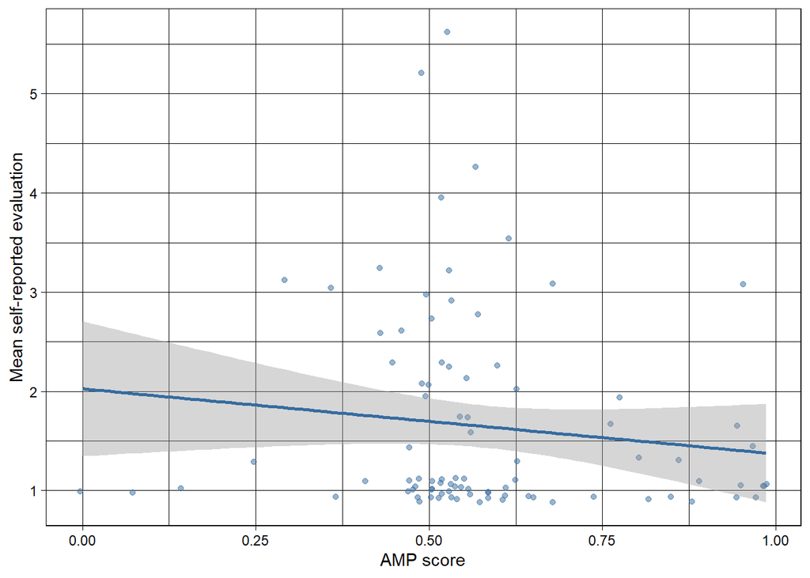

```r
ggplot(data_processed_after_exclusions,
       aes(x = AMP_score,
           y = mean_evaluation)) +
  geom_jitter(color = viridis_pal(begin = 0.45, option = "mako")(1),
              alpha = 0.5) +
  geom_smooth(method = "lm",
              color = viridis_pal(begin = 0.45, option = "mako")(1)) +
  xlab("AMP score") +
  ylab("Mean self-reported evaluation") +
  theme_linedraw()
```

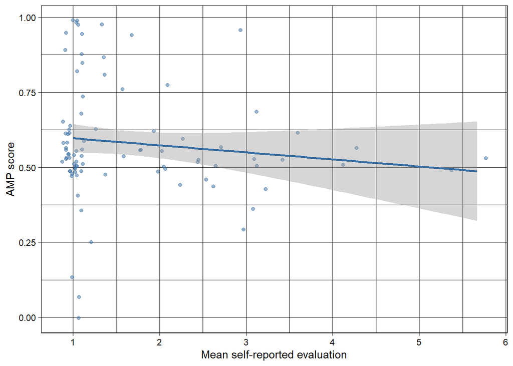

```r
ggplot(data_processed_after_exclusions,
       aes(y = AMP_score,
           x = mean_evaluation)) +
  geom_jitter(color = viridis_pal(begin = 0.45, option = "mako")(1),
              alpha = 0.5) +
  geom_smooth(method = "lm",
              color = viridis_pal(begin = 0.45, option = "mako")(1)) +
  ylab("AMP score") +
  xlab("Mean self-reported evaluation") +
  theme_linedraw()
```

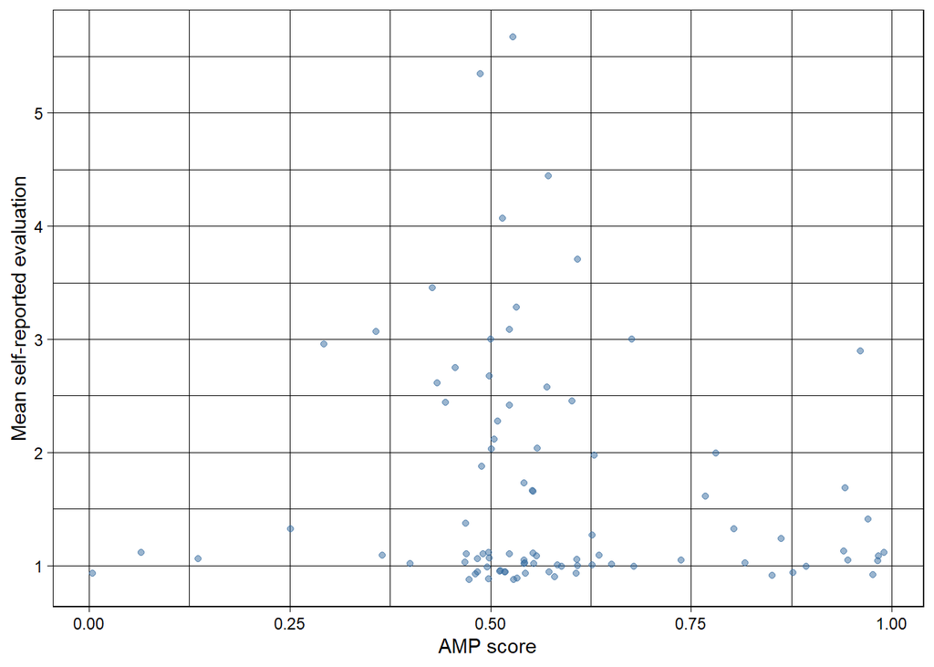

```r
ggplot(data_processed_after_exclusions,
       aes(x = AMP_score,
           y = mean_evaluation)) +
  geom_jitter(color = viridis_pal(begin = 0.45, option = "mako")(1),
              alpha = 0.5) +
  xlab("AMP score") +
  ylab("Mean self-reported evaluation") +
  theme_linedraw()
```

More complex plots:

#### Axial hisograms

Scatter plots with axial histograms using ggExtra: https://cran.r-project.org/web/packages/ggExtra/vignettes/ggExtra.html

add axial histograms to a scatter plot. In a single plot, present different regression lines split by gender, and separate axial histograms for each gender.

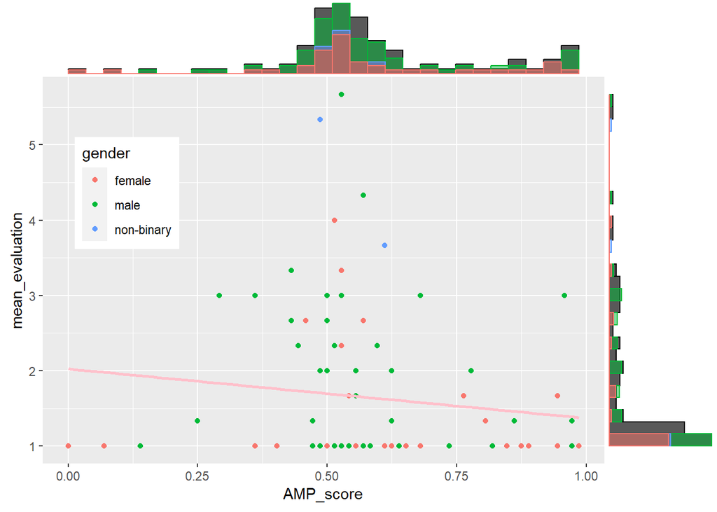

```r
library("ggExtra")
library("ggplot2")


#creating a plot
plot1 <- ggplot(data_processed_after_exclusions,
       aes(x = AMP_score,
           y = mean_evaluation)) +
  geom_jitter(color = viridis_pal(begin = 0.45, option = "mako")(1),
              alpha = 0.5) +
  xlab("AMP score") +
  ylab("Mean self-reported evaluation") +
  theme_linedraw()

ggMarginal(plot1, type = "histogram")


#Split them by gender and add regression line

Axial_histogram_gender <- ggplot(data_processed_after_exclusions,
                                  aes(x = AMP_score,
                                      y = mean_evaluation,
                                      colour = gender)) +
  geom_point() +
  geom_smooth(method = "lm", se = FALSE, color = "pink") +  # Add regression line
  scale_colour_discrete(name = "gender",
                        labels = c("female", "male", "non-binary")) +
  theme(legend.position = c(.15, .7))

ggMarginal(Axial_histogram_gender, type = "histogram", groupColour = TRUE, groupFill = TRUE)
```

```r
#The regression line kinda shows a negative trend --> important to observe a first trend
```

#### Labelled points

Label points using ggrepel: https://cran.r-project.org/web/packages/ggrepel/vignettes/ggrepel.html

Label the points in a scatter plot using their participant codes. Label only the participants with more extreme scores.

```r
library(ggrepel)
```

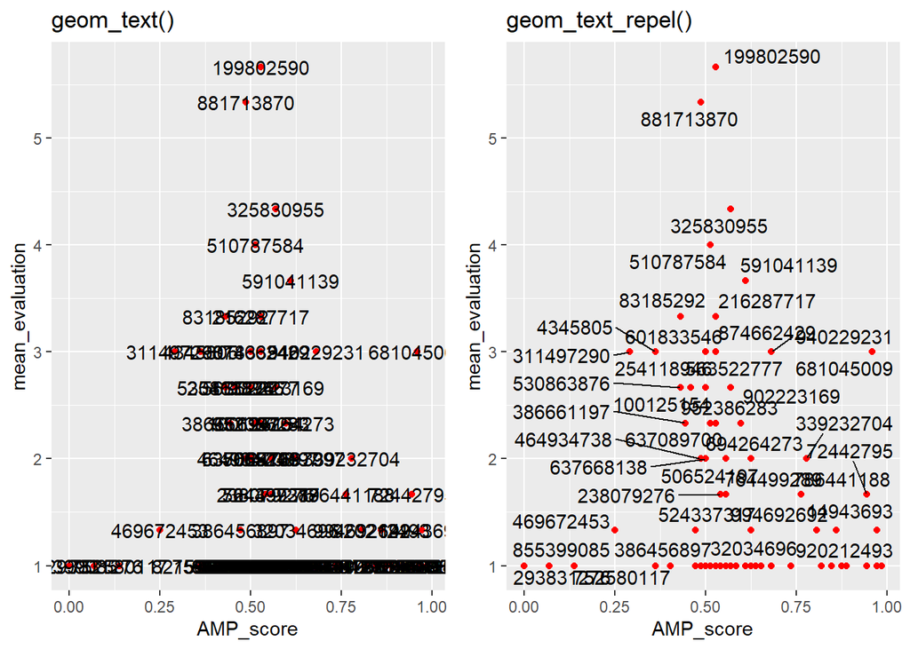

```r
#Plot
Point_labels <- ggplot(data_processed_after_exclusions,
       aes(x = AMP_score,
           y = mean_evaluation,
           label = subject)) +
  geom_point (color = "red") +
  scale_colour_discrete(name = "gender",
                        labels = c("female", "male", "non-binary"))

set.seed(42)

p1 <- Point_labels + geom_text() + labs(title = "geom_text()")

p2 <- Point_labels + geom_text_repel() + labs(title = "geom_text_repel()")

gridExtra::grid.arrange(p1, p2, ncol = 2)
```

```r
#R itself gives us a warning, that there are unlabeled data points and too many overlaps, so this plot is not really useful
#a way this plot is often used is to show the outliers or identify them, this is easily done by just putting the outlier variable or an order reporting the outliers directly in to the ggplot
```

#### Magnify areas

Magnify areas of your plot with ggmagnify: https://hughjonesd.github.io/ggmagnify/

Magnify an area of one of your scatter plots, eg where there are a lot of data points in a small area.

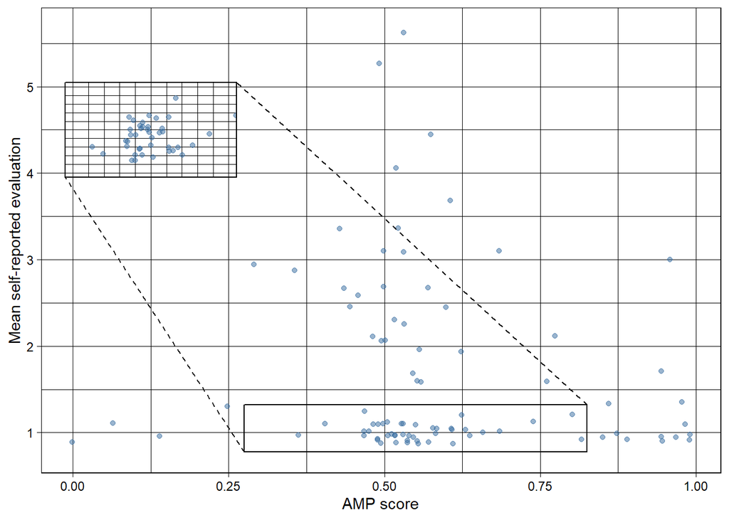

```r
# Load necessary libraries
library(ggplot2)
library(ggmagnify)

# Your original scatter plot
ggp <- ggplot(data_processed_after_exclusions, aes(x = AMP_score, y = mean_evaluation)) +
  geom_jitter(color = viridis_pal(begin = 0.45, option = "mako")(1), alpha = 0.5) +
  xlab("AMP score") +
  ylab("Mean self-reported evaluation") +
  theme_linedraw()

# Define the area to be magnified
# Adjust these values to the area you want to zoom in on
from <- c(xmin = 0.3, xmax = 0.8, ymin = 0.8, ymax = 1.3)

# Define where to place the magnified inset on the plot
# Adjust these values to place the inset where you like
to <- c(xmin = 0, xmax = 0.25, ymin = 4, ymax = 5)

# Add the magnified area to the plot
ggp + geom_magnify(from = from, to = to)
```

### Test

run an appropriate test. Below the output, interpret the results: write a few sentences that report and interpret the results following APA reporting style. Statistical inference test —> Test stats and p value Hypothesis: Self-reported evaluations are correlated with evaluations on the AMP

```r
# In order tot check whether self report evaluations are correlated with the amp evaluations we remember the regression line above where we saw a slight negative trend We should test this statistically
result <- cor.test(data_processed_after_exclusions$mean_evaluation, data_processed_after_exclusions$AMP_score, method = "pearson")

# Print the test statistics and p-value
print(result)
```

```
##
##  Pearson's product-moment correlation
##
## data:  data_processed_after_exclusions$mean_evaluation and data_processed_after_exclusions$AMP_score
## t = -1.1742, df = 88, p-value = 0.2435
## alternative hypothesis: true correlation is not equal to 0
## 95 percent confidence interval:
##  -0.32298009  0.08508347
## sample estimates:
##       cor
## -0.124196
```

```r
#if we want the results specifically
 result$p.value
```

```
## [1] 0.2435018
```

```r
 result$estimate
```

```
##       cor
## -0.124196
```

```r
#we see a negative correlation however it is not significant (p = .2435), also seen in confidence interval that includes 0 suggesting that there is no correlation in the data

# we can alos check for a spearman correlation test
 result2 <- cor.test(data_processed_after_exclusions$mean_evaluation, data_processed_after_exclusions$AMP_score, method = "spearman")

 result2$p.value
```

```
## [1] 0.231376
```

```r
 result2$estimate
```

```
##        rho
## -0.1274223
```

```r
#for the spearman it is almost identical (not surprisingly)
```

## Self-reported evalautions differ between men and women

### Plot

split histogram, split violin plot, raincloud plot, etc.

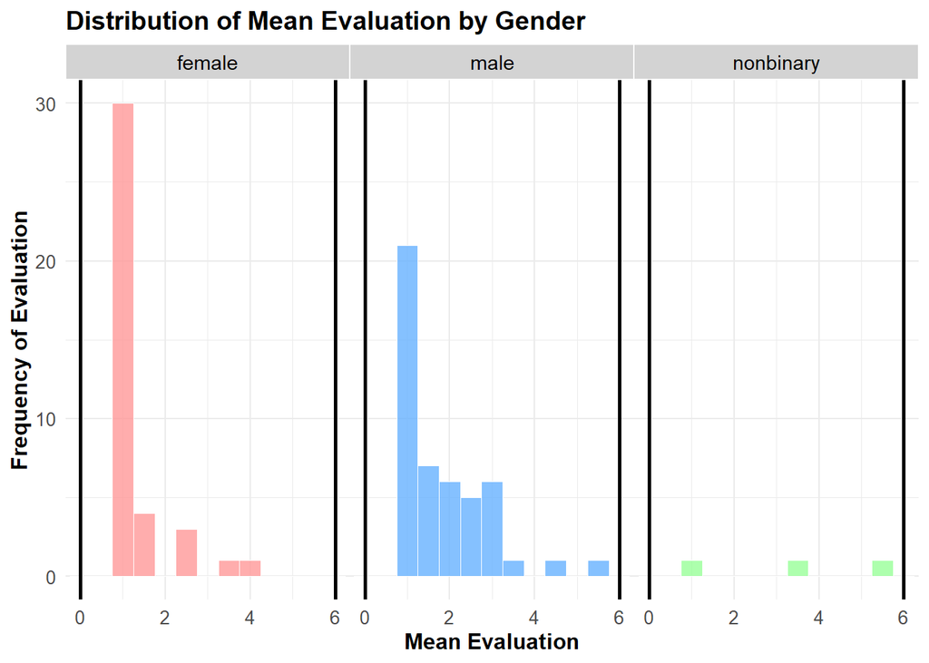

```r
#####split histogram

library(ggplot2)
library(hrbrthemes)  #really cool package for better themes

# I choose the theme ipsum (very clean there is a lot of different ones)
theme_set(theme_ipsum())

# Plotting
splithistogram <- ggplot(data_processed_after_exclusions, aes(x = mean_evaluation, fill = gender)) +
  geom_histogram(position = "dodge", binwidth = 0.5, color = "white", alpha = 0.8, size = 0.2) +
  geom_vline(xintercept = seq(0, 6, by = 6), color = "black", size = 1) + #put in lines in order to  distinguish the plots if you don't they are all kinda squished together
  facet_wrap(~ gender, scales = "free_x") +
  xlab("Mean Evaluation") +
  ylab("Frequency of Evaluation") +
  labs(title = "Distribution of Mean Evaluation by Gender") +
  scale_fill_manual(values = c("female" = "#FF9999", "male" = "#66B2FF", "nonbinary" = "#99FF99"), guide = FALSE) + #sometimes this does not work (--> if it does not set to NONE)
  theme_minimal() +
  theme(#This is for te legend bars (really practical for some things)
    legend.position = "top",
    legend.background = element_rect(fill = "white"),
    strip.background = element_rect(fill = "lightgray", color = "white"),
    strip.text = element_text(color = "black", size = 11),
    axis.text.x = element_text(size = 10),
    axis.text.y = element_text(size = 10),
    axis.title = element_text(size = 12, face = "bold"),
    plot.title = element_text(size = 14, face = "bold"),
    panel.spacing = unit(0.0, "lines")  #Here we can reduce the space between the bars
  ) +
  theme(
    axis.text.x = element_text(size = 10),
    axis.text.y = element_text(size = 10),
    axis.title = element_text(size = 12, face = "bold"),
    plot.title = element_text(size = 14, face = "bold")
  ) +
  scale_x_continuous(expand = c(0.05, 0.05)) + # Adjust the space on the x axis (both ends)
  coord_cartesian(xlim = c(0, 6))  # Since we have a scale from 1-6 we can fix the scale for all to show from 1-6 in order to see the distribution
# Print the plot
print(splithistogram)
```

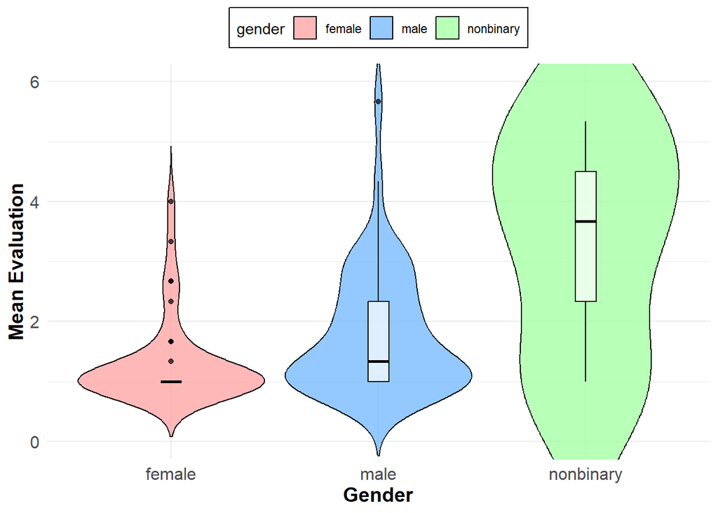

```r
#With regard to the hypothesis we see a differing distribution which could lead to a significant hypothesis (men and women differing in their self reports)


##### Violin Plot
#Theme
theme_set(theme_ipsum_ps()) # choosing a different theme this time in order to experiment a bit

# Violin Plot
splitviolin <- ggplot(data_processed_after_exclusions, aes(x = gender, y = mean_evaluation, fill = gender)) +
  geom_violin(scale = "width", trim = FALSE, alpha = 0.7, color = "black") +
  geom_boxplot(width = 0.1, fill = "white", color = "black", alpha = 0.7) +
  xlab("Gender") +
  ylab("Mean Evaluation") +
  theme_minimal() +
  theme(
    legend.position = "top", #we put top instead of a vector since it is not pretty with the vector (see above how to do with a vector)
    legend.background = element_rect(fill = "white"),
    axis.text.x = element_text(size = 12),
    axis.text.y = element_text(size = 12),
    axis.title = element_text(size = 14, face = "bold"),
    plot.title = element_text(size = 16, face = "bold"),
    panel.spacing = unit(0.0, "lines")) +
  scale_fill_manual(values = c("female" = "#FF9999", "male" = "#66B2FF", "nonbinary" = "#99FF99")) +
  coord_cartesian(ylim = c(0, 6))

# Print
print(splitviolin)
```

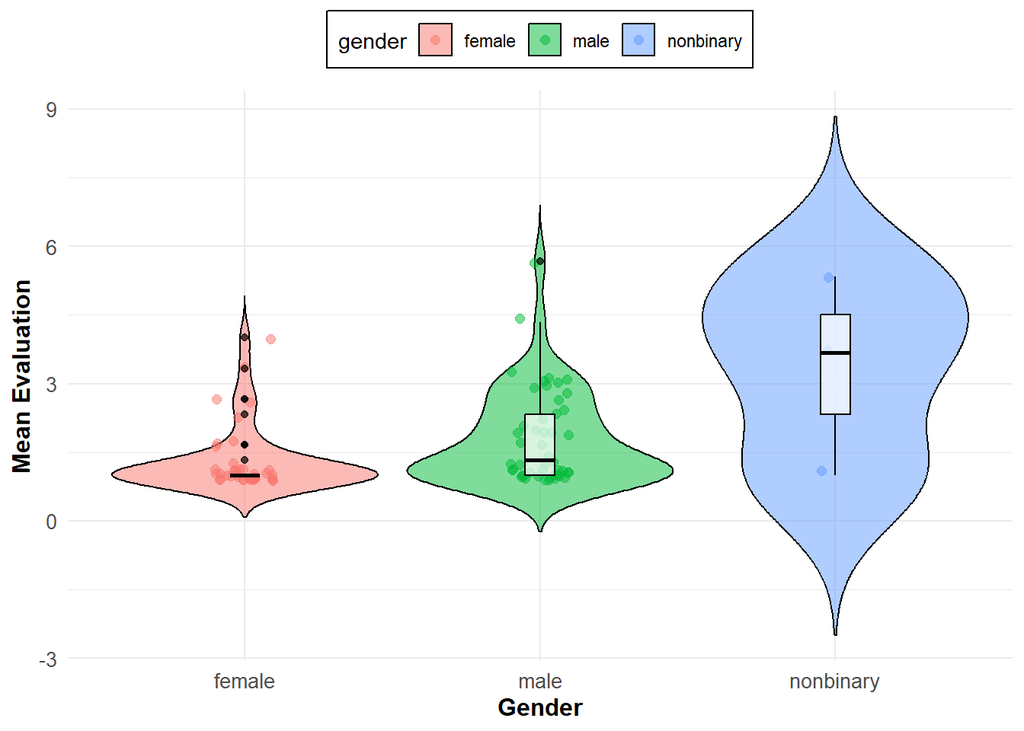

```r
#The violin plot offers a bit more information on the distribution of the self evaluations. Since there are so little people having a nonbinary gender the wide distribution is not surprising. Whereas for men and women there is more to interpret --> The median is different and women have a less higher distribution also suggesting that the two genders might differ.


#####raincloud plot
library(ggplot2)
library(ggdist)#used for flat violin
library(hrbrthemes)


# Set the theme
theme_set(theme_ipsum())


raincloudplot <- ggplot(data_processed_after_exclusions, aes(x = gender, y = mean_evaluation, fill = gender)) +
  geom_violin(scale = "width", trim = FALSE, alpha = 0.5, color = "black") +
  geom_point(aes(color = gender), position = position_jitter(width = 0.1), size = 2, alpha = 0.5) +
  geom_boxplot(width = 0.1, fill = "white", color = "black", alpha = 0.7) +
  labs(x = "Gender", y = "Mean Evaluation") +
  theme_minimal() +
  theme(
    legend.position = "top",  # Adjust legend position to the top
    legend.background = element_rect(fill = "white"),
    axis.text.x = element_text(size = 10),
    axis.text.y = element_text(size = 10),
    axis.title = element_text(size = 12, face = "bold"),
    plot.title = element_text(size = 14, face = "bold"))



# Print the plot
print(raincloudplot)
```

```r
#The raincloud plot suggests the same as above with women having some outliers where men still have distribution in violin plot. The overall plotting suggests that the hypothesis is supported.
```

### Test

run an appropriate test. Below the output, interpret the results: write a few sentences that report and interpret the results following APA reporting style.

Self-reported evalautions differ between men and women

```r
#T-Test to check for possible differences

#Create one dataset for male and female
data_male <- subset(data_processed_after_exclusions, gender == "male")
data_female <- subset(data_processed_after_exclusions, gender == "female")


#doing a T-Test with the mean_evaluation self reports
t_test_result <- t.test(mean_evaluation ~ gender, data = rbind(data_male, data_female))

#Printing the results in order to see whether it is significant or not:
print(t_test_result)
```

```
##
##  Welch Two Sample t-test
##
## data:  mean_evaluation by gender
## t = -2.616, df = 83.137, p-value = 0.01056
## alternative hypothesis: true difference in means between group female and group male is not equal to 0
## 95 percent confidence interval:
##  -0.8613407 -0.1172918
## sample estimates:
## mean in group female   mean in group male
##             1.316239             1.805556
```

```r
library(report)
report_table(t_test_result)
```

```
## Welch Two Sample t-test
##
## Parameter       |  Group | Mean_Group1 | Mean_Group2 | Difference |         95% CI | t(83.14) |     p |     d |          d  CI
## ------------------------------------------------------------------------------------------------------------------------------
## mean_evaluation | gender |        1.32 |        1.81 |      -0.49 | [-0.86, -0.12] |    -2.62 | 0.011 | -0.57 | [-1.01, -0.13]
##
## Alternative hypothesis: two.sided
```

```r
report_effectsize(t_test_result)
```

```
## Effect sizes were labelled following Cohen's (1988) recommendations.
##
## medium (Cohen's d = -0.57, 95% CI [-1.01, -0.13])
```

```r
report_text(t_test_result)
```

```
## Effect sizes were labelled following Cohen's (1988) recommendations.
##
## The Welch Two Sample t-test testing the difference of mean_evaluation by gender
## (mean in group female = 1.32, mean in group male = 1.81) suggests that the
## effect is negative, statistically significant, and medium (difference = -0.49,
## 95% CI [-0.86, -0.12], t(83.14) = -2.62, p = 0.011; Cohen's d = -0.57, 95% CI
## [-1.01, -0.13])
```

```r
#If a T-Test is not possible (this is the case when there is more than two independent groups) we can conduct a Kruskal_Wallis-Test. If we would like to include all genders (not only men and women), a Kruskal test is appropriate.

kruskal_result <- kruskal.test(mean_evaluation ~ gender, data = data_processed_after_exclusions)

# Print the result
print(kruskal_result)
```

```
##
##  Kruskal-Wallis rank sum test
##
## data:  mean_evaluation by gender
## Kruskal-Wallis chi-squared = 11.185, df = 2, p-value = 0.003726
```

```r
#Similarly, the Kruskal-Wallis test confirms the previously indicated significance. Likewise the p-value is clearly below 0.5 (p= 0.0037) and thus indicates a significant difference with regard to the self-reported average evaluation in men, women and non-binary individuals.
```

## Evaluations on the Affect Misattribution Procedure differ between men and women

### Plot

split histogram, split violin plot, raincloud plot, etc.

This time, vary the labeling and order of the legend, e.g., capitalise “Men” and “Women”, and know how to change the order of the factors.

[figure not shown]

```r
#####Split Histogram
#vary the labeling and order of the legend
# We can define custom labels and vary their order so the legend shows different things
custom_labels <- c( "Women", "Non-binary", "Men") # here we can vary the names and order within the legend
custom_order <- c("female", "nonbinary", "male" ) #with this we can adjust the custom order

#ATTENTION: The order of the custom labels and order has to be the same otherwhise the legend and the order is not matched

#In order to be able to reorder them we have to change the factor since otherwhise there is absolutely nothing happening
data_processed_after_exclusions$gender <- factor(data_processed_after_exclusions$gender,
                                                 levels = custom_order)

#we can then easily insert them into our splithistogram like that
splithistogram2 <- ggplot(data_processed_after_exclusions, aes(x = AMP_score, fill = gender)) +
  geom_histogram(position = "dodge", binwidth = 0.15, color = "black", alpha = 0.7) +
  facet_grid(. ~ gender) +
  xlab("AMP score") +
  ylab("Mean self-reported evaluation") +
  theme_minimal() +
  theme(legend.position = c(0.51, 0.8), legend.background = element_rect(fill = "white")) +
  scale_fill_manual(values = c("female" = "red", "male" = "blue", "nonbinary" = "green"),
                    labels = custom_labels) +
  labs(fill = "Gender")  # We could also capitalize the header (title) of the legend


# Print the plot
print(splithistogram2)
```

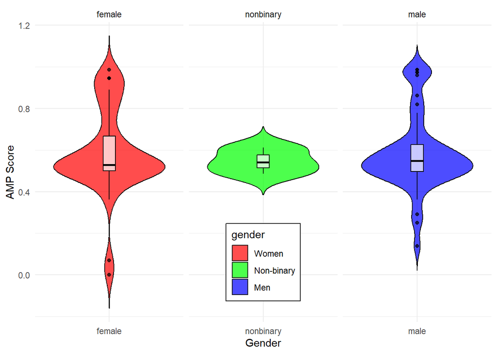

```r
#As we can see the legend is changed now with all things being capitalized --> in order to change them again we can adjust the vector



#####Split violin plot
#change the order of the violin plot (same as above) --> it is the same custom labels and order if we would like different ones we would have to name them differently in order to not get things mixed up
custom_labels <- c( "Women", "Non-binary", "Men")
custom_order <- c("female", "nonbinary", "male" )

# Reorder the level
data_processed_after_exclusions$gender <- factor(data_processed_after_exclusions$gender,
                                                 levels = custom_order)

# Split violin with the legend being modified
splitviolin2 <- ggplot(data_processed_after_exclusions, aes(x = gender, y = AMP_score, fill = gender)) +
  geom_violin(scale = "width", trim = FALSE, alpha = 0.7, color = "black") +
  geom_boxplot(width = 0.1, fill = "white", color = "black", alpha = 0.7) +
  facet_wrap(~gender, scales = "free_x") +
  xlab("Gender") +
  ylab("AMP Score") +
  theme_minimal() +
  theme(legend.position = c(0.5, 0.2), legend.background = element_rect(fill = "white")) +
  scale_fill_manual(values = c("female" = "red", "male" = "blue", "nonbinary" = "green"),
                    labels = custom_labels,
                    breaks = custom_order)

# Print the plot
print(splitviolin2)
```

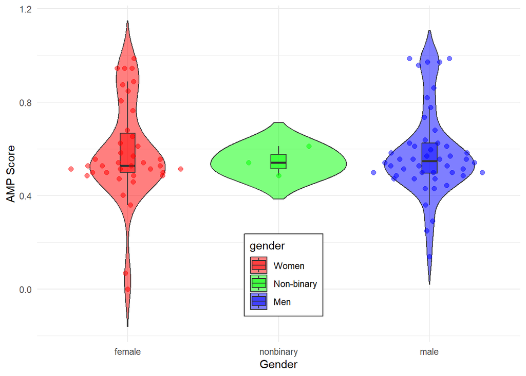

```r
##### Raincloud plot
library(ggbeeswarm)

#We are again taking our same labels as above ( we do not have to read them in all of the time but it is better to have an intersubjective view of what happened)
custom_labels <- c( "Women", "Non-binary", "Men")
custom_order <- c("female", "nonbinary", "male" )

#reorder the levels (again same thing as previously done)
data_processed_after_exclusions$gender <- factor(data_processed_after_exclusions$gender,
                                                 levels = custom_order)


#Create the plot
raincloudplot2 <- ggplot(data_processed_after_exclusions, aes(x = gender, y = AMP_score, fill = gender)) +
  geom_violin(trim = FALSE, scale = "area", adjust = 1.5, alpha = 0.5) +
  geom_boxplot(width = 0.1, outlier.shape = NA, alpha = 0.5) +
  geom_quasirandom(aes(color = gender, fill = gender), size = 2, alpha = 0.5, show.legend = FALSE) +
  scale_color_manual(values = c("female" = "red", "male" = "blue", "nonbinary" = "green"),  #we adjust the colours because otherwise the points and plots do not match
                    labels = custom_labels,
                    breaks = custom_order) +
  scale_fill_manual(values = c("female" = "red", "male" = "blue", "nonbinary" = "green"),
                    labels = custom_labels,
                    breaks = custom_order) +
  labs(x = "Gender", y = "AMP Score") +
  theme_minimal() +
  theme(legend.position = c(0.51, 0.2), legend.background = element_rect(fill = "white"))


# Print the plot
print(raincloudplot2)
```

### Test

Hypothesis from above: Evaluations on the Affect Misattribution Procedure differ between men and women

run an appropriate test. Below the output, print an interpretation of the results generated by the ‘easystats’ package [report](https://easystats.github.io/report/). I.e., use `report::report()`.

```r
#t test


data_tests <- rbind(data_male, data_female)


AMP_t_test_result <- t.test(AMP_score ~ gender, data = data_tests)
print(AMP_t_test_result)
```

```
##
##  Welch Two Sample t-test
##
## data:  AMP_score by gender
## t = 0.073308, df = 76.079, p-value = 0.9418
## alternative hypothesis: true difference in means between group female and group male is not equal to 0
## 95 percent confidence interval:
##  -0.08270667  0.08902789
## sample estimates:
## mean in group female   mean in group male
##            0.5847578            0.5815972
```

```r
report_table(AMP_t_test_result)
```

```
## Welch Two Sample t-test
##
## Parameter |  Group | Mean_Group1 | Mean_Group2 | Difference |        95% CI | t(76.08) |     p |    d |         d  CI
## ---------------------------------------------------------------------------------------------------------------------
## AMP_score | gender |        0.58 |        0.58 |   3.16e-03 | [-0.08, 0.09] |     0.07 | 0.942 | 0.02 | [-0.43, 0.47]
##
## Alternative hypothesis: two.sided
```

```r
report_effectsize(AMP_t_test_result)
```

```
## Effect sizes were labelled following Cohen's (1988) recommendations.
##
## very small (Cohen's d = 0.02, 95% CI [-0.43, 0.47])
```

```r
report_text(AMP_t_test_result)
```

```
## Effect sizes were labelled following Cohen's (1988) recommendations.
##
## The Welch Two Sample t-test testing the difference of AMP_score by gender (mean
## in group female = 0.58, mean in group male = 0.58) suggests that the effect is
## positive, statistically not significant, and very small (difference = 3.16e-03,
## 95% CI [-0.08, 0.09], t(76.08) = 0.07, p = 0.942; Cohen's d = 0.02, 95% CI
## [-0.43, 0.47])
```

## Combining plots

Combine plots using the library [patchwork](https://patchwork.data-imaginist.com/).

Combine at least three of the above plots into one.

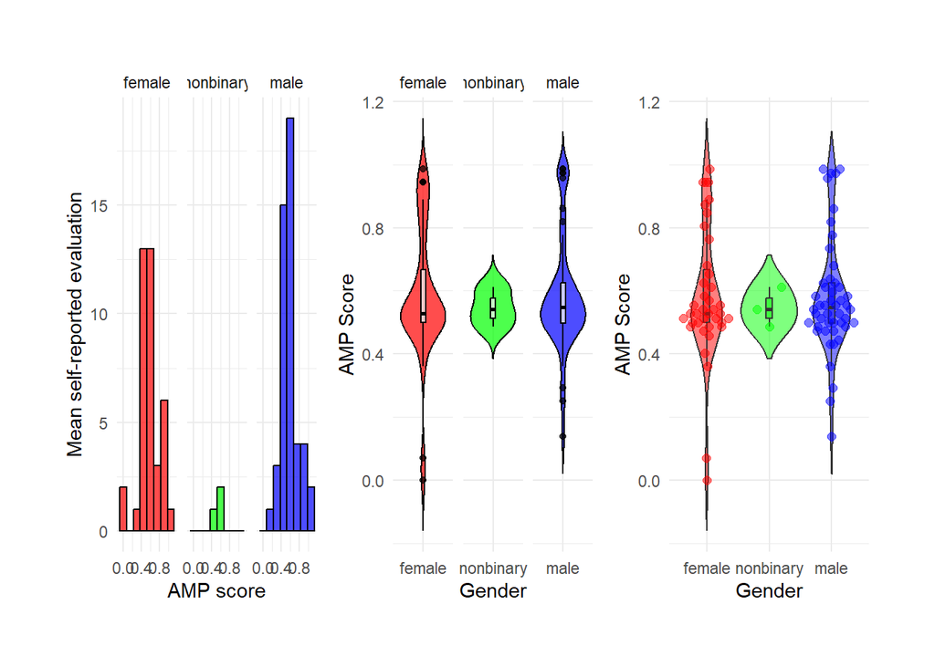

```r
# you can combine things with patchwork
library(patchwork)


#First we have to remove the legends from the plots
splithistogram2_plot <- splithistogram2 + theme(legend.position = "none")
splitviolin2_plot <- splitviolin2 + theme(legend.position = "none")
raincloudplot2_plot <- raincloudplot2 + theme(legend.position = "none")

#Combining a plot (with +)
combined_plot <- splithistogram2_plot + splitviolin2_plot + raincloudplot2_plot


print(combined_plot)
```

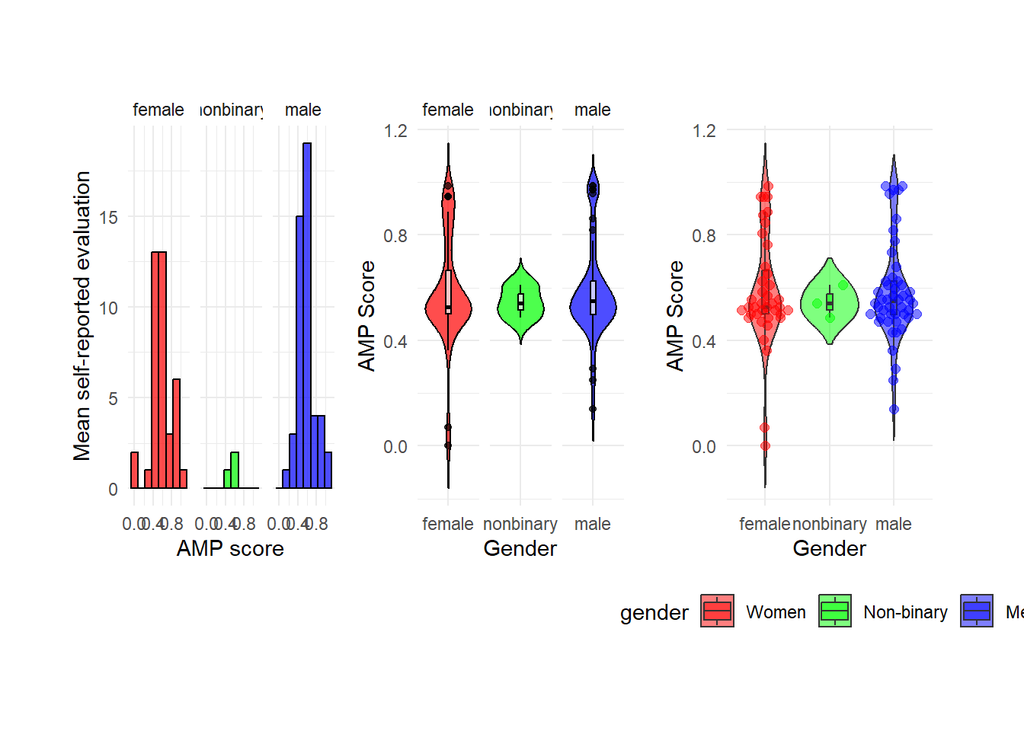

```r
#This does not look too pretty so you can modify the codes


# Customize the appearance of the combined plot
combined_plot <- (splithistogram2_plot + splitviolin2_plot + raincloudplot2_plot +
  plot_layout(ncol = 3) +  # Set the number of columns
  theme_minimal() +        # Use a minimal theme
  theme(
    plot.margin = margin(15, 15, 15, 15),  # Adjust overall margins
    strip.text = element_text(size = 10),   # Adjust text size in facet labels
    legend.position = "bottom",             # Move the legend to the bottom
    legend.direction = "horizontal",        # Arrange legend items horizontally
    legend.box = "horizontal"                # Use a horizontal legend box
  )
)

# Print the customized combined plot
print(combined_plot)
```

## Saving plots

Save plots to disk with `ggsave()`

Save the above combined plot to disk as both .png and .pdf. Ensure the png has at least 300dpi resolution.

```r
ggsave("combined_plot.png", combined_plot, width = 15, height = 5, units = "in", dpi = 300)

ggsave("combined_plot.pdf", combined_plot, width = 15, height = 5, units = "in", dpi = 300)

#Both of them are in the same folder as analysis and processing
```